# Macfarlan Chr4 h3k4me3

Aditya Mahadevan

4/26/2020

```r
knitr::opts_chunk$set(echo = TRUE)
options(stringsAsFactors = FALSE)
setwd("~/Documents/MacFarlan chr4 B6 testis H3K4me3") #setting the working directory
# load some libraries
library(tidyverse) # for data manipulation and working with data frames
library(edgeR) # for normalizing data and performing differential expression
library(GenomicRanges) # for working with bed files in R
```

### Load data

We are going to load read counts for H3K4me3 ChIP-seq from mouse B6 testis. This data was published in part from [bioRxiv: Non-essential function of KRAB zinc finger gene clusters in retrotransposon suppression](https://www.biorxiv.org/content/10.1101/2020.01.17.910679v1.supplementary-material).

These data were remapped to mm10 using bwa and peaks called with MACS 1.4.2.

The peakome includes peaks identified in both WT cells and those with a region of chr4 deleted using CRISPR

```r
df <- read.table(file = "H3K4me3_B6_chr4cl_Testis_peakome.txt", header = TRUE) # read counts from Macfarlan ChIP
qtl.targets <- read.table(file = "BXD_germcells_chr4_qtl_targets_h3k4me3.txt", header = TRUE) # Chr 4 QTL targets in BXDs germ cells
```

Our peakome has n = 50540 peaks.

### Set up useful functions for intersecting two bed files in R

```r
# Function to take intersect two bed files using GRanges
intersect_bed <- function(x, y){
  # load into GRanges object
  a <- makeGRangesFromDataFrame(x, keep.extra.columns = T)
  b <- makeGRangesFromDataFrame(y, keep.extra.columns = T)
  # find overlaps
  my_hit <- findOverlaps(a, b)
  my_df  <- data.frame(b[subjectHits(my_hit)])
}
```

Normalize using Bioconductor package edgeR

```r
y <- DGEList(counts=df[,4:5])
### TMM normalization
y <- calcNormFactors(y)

### Export data from DGE object
data.cpm <- as.data.frame(cpm(y, normalized.lib.sizes = TRUE)) # export cpm with TMM normalization
data <- round(log2(data.cpm + 1), 4) # log2 transform
### combine normalized data with genomic regions
df.norm <- cbind(df[,1:3], data)

keep <- rowSums(cpm(y)>1) <= 2 # apply filter for peaks with cpm > 1 across both samples
df.filter <- df.norm[keep, ]
```

Calculate average and log2 fold change between wt and ko

```r
df.filter$ave <- (df.filter$WT+df.filter$KO)/2
df.filter$log2FC <- df.filter$WT-df.filter$KO
```

A few plots to look at the normalized data

####Histogram Plot distribution of log2FC

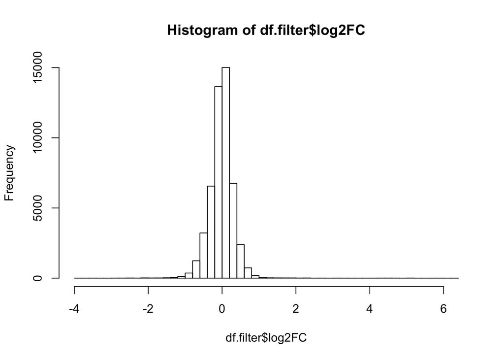

```r
hist(df.filter$log2FC, breaks = 50)
```

Notice now that the average is around 0 opposed to prior to normalization.

####MA-plot MA-plots plot the average vs log2FC

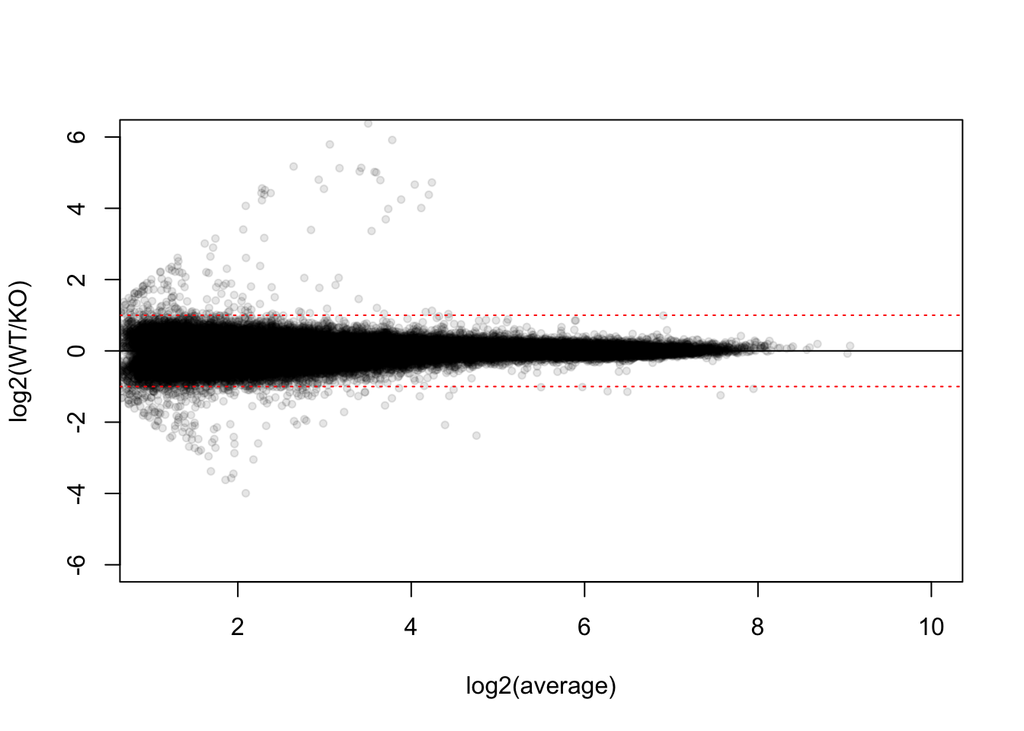

```r
plot(df.filter$ave, df.filter$log2FC,
     pch = 20,
     col = rgb(0,0,0, 0.1),
     xlim = c(1,10),
     ylim = c(-6,6),
     xlab = "log2(average)",
     ylab = "log2(WT/KO)")
abline(h = 0, col = "black")
abline(h = 1, col = "red", lty = 3)
abline(h = -1, col = "red", lty = 3)
```

There are a number of peaks that are much higher in the wild-type. I propose that these are from the Chr 4 deletion region. We can also see that there are a *greater* number of peaks that have more modification in the KO. These are likely the targets we are interested in since KRAB-ZFPs/Trim28 act to suppress chromatin. When you remove the suppressor, perhaps regions are now available to be opened?

```r
cutoff <- 2
wt <- df.filter %>%
  filter(log2FC > cutoff)
knitr::kable(wt)
```

| chr | start | end | WT | KO | ave | log2FC |
| --- | --- | --- | --- | --- | --- | --- |
| chr1 | 128638115 | 128638724 | 2.2083 | 0.0000 | 1.10415 | 2.2083 |
| chr14 | 26009170 | 26010891 | 2.4329 | 0.2166 | 1.32475 | 2.2163 |
| chr14 | 26148789 | 26150485 | 2.4949 | 0.1124 | 1.30365 | 2.3825 |
| chr14 | 26288438 | 26290146 | 2.4147 | 0.0573 | 1.23600 | 2.3574 |
| chr14 | 43795863 | 43798620 | 4.1880 | 2.1383 | 3.16315 | 2.0497 |
| chr14 | 43924849 | 43926319 | 3.0253 | 0.7208 | 1.87305 | 2.3045 |
| chr14 | 45858160 | 45859466 | 2.2189 | 0.0000 | 1.10945 | 2.2189 |
| chr14 | 46502070 | 46504365 | 3.8884 | 0.7208 | 2.30460 | 3.1676 |
| chr14 | 50978150 | 50979342 | 3.3984 | 0.7900 | 2.09420 | 2.6084 |
| chr14 | 52128316 | 52129932 | 3.4485 | 1.0660 | 2.25725 | 2.3825 |
| chr14 | 52839625 | 52841508 | 3.1238 | 0.1124 | 1.61810 | 3.0114 |
| chr14 | 53150655 | 53152693 | 3.1625 | 0.2661 | 1.71430 | 2.8964 |
| chr14 | 54231944 | 54234926 | 4.5404 | 1.1474 | 2.84390 | 3.3930 |
| chr14 | 63469847 | 63471126 | 2.5708 | 0.0573 | 1.31405 | 2.5135 |
| chr14 | 66173999 | 66175324 | 2.1324 | 0.1124 | 1.12240 | 2.0200 |
| chr14 | 81301628 | 81303272 | 3.7894 | 1.7439 | 2.76665 | 2.0455 |
| chr15 | 34152759 | 34154575 | 3.0072 | 0.3601 | 1.68365 | 2.6471 |
| chr15 | 95205168 | 95206749 | 2.4509 | 0.2661 | 1.35850 | 2.1848 |
| chr17 | 50420841 | 50422822 | 2.7557 | 0.5715 | 1.66360 | 2.1842 |
| chr4 | 145462900 | 145465199 | 6.0065 | 1.7612 | 3.88385 | 4.2453 |
| chr4 | 145584622 | 145586262 | 4.1250 | 0.0573 | 2.09115 | 4.0677 |
| chr4 | 145639747 | 145642093 | 6.1197 | 2.1115 | 4.11560 | 4.0082 |
| chr4 | 145744254 | 145746526 | 6.0870 | 1.0660 | 3.57650 | 5.0210 |
| chr4 | 145773469 | 145775956 | 5.5513 | 1.8611 | 3.70620 | 3.6902 |
| chr4 | 145780549 | 145782698 | 4.4870 | 0.0573 | 2.27215 | 4.4297 |
| chr4 | 145835878 | 145838244 | 6.6932 | 0.3139 | 3.50355 | 6.3793 |
| chr4 | 146066218 | 146068765 | 6.3728 | 1.7086 | 4.04070 | 4.6642 |
| chr4 | 146238490 | 146240788 | 6.0985 | 1.0937 | 3.59610 | 5.0048 |
| chr4 | 146262356 | 146264706 | 5.3337 | 0.5316 | 2.93265 | 4.8021 |
| chr4 | 146269638 | 146271526 | 4.4978 | 0.1124 | 2.30510 | 4.3854 |
| chr4 | 146473976 | 146476402 | 6.7388 | 0.8234 | 3.78110 | 5.9154 |
| chr4 | 146514259 | 146515556 | 2.6113 | 0.0000 | 1.30565 | 2.6113 |
| chr4 | 146579135 | 146581291 | 6.0388 | 1.2493 | 3.64405 | 4.7895 |
| chr4 | 146602956 | 146605592 | 5.2655 | 0.7208 | 2.99315 | 4.5447 |
| chr4 | 146610343 | 146612244 | 4.5919 | 0.1655 | 2.37870 | 4.4264 |
| chr4 | 146931635 | 146933720 | 4.3902 | 0.1655 | 2.27785 | 4.2247 |
| chr4 | 146941216 | 146943330 | 5.7266 | 1.7439 | 3.73525 | 3.9827 |
| chr4 | 147086199 | 147087486 | 2.7411 | 0.5316 | 1.63635 | 2.2095 |
| chr4 | 147101080 | 147102985 | 5.7358 | 0.6103 | 3.17305 | 5.1255 |
| chr4 | 147113479 | 147114866 | 2.0044 | 0.0000 | 1.00220 | 2.0044 |
| chr4 | 147124080 | 147126443 | 5.9913 | 0.8561 | 3.42370 | 5.1352 |
| chr4 | 147131254 | 147133305 | 4.5592 | 0.0000 | 2.27960 | 4.5592 |
| chr4 | 147186541 | 147188793 | 5.9571 | 0.1655 | 3.06130 | 5.7916 |
| chr4 | 147274486 | 147276770 | 6.6002 | 1.8771 | 4.23865 | 4.7231 |
| chr4 | 147406053 | 147408216 | 5.2243 | 1.8611 | 3.54270 | 3.3632 |
| chr4 | 147442369 | 147444803 | 5.9221 | 0.8880 | 3.40505 | 5.0341 |
| chr4 | 147448474 | 147450580 | 3.3174 | 0.1655 | 1.74145 | 3.1519 |
| chr4 | 147552991 | 147553780 | 2.3682 | 0.1124 | 1.24030 | 2.2558 |
| chr4 | 147737709 | 147739700 | 6.3921 | 2.0136 | 4.20285 | 4.3785 |
| chr4 | 147808622 | 147810440 | 4.5695 | 0.0573 | 2.31340 | 4.5122 |
| chr4 | 147847288 | 147849360 | 5.2295 | 0.0573 | 2.64340 | 5.1722 |
| chr6 | 71737766 | 71739987 | 3.7645 | 0.3601 | 2.06230 | 3.4044 |
| chr6 | 71859177 | 71860660 | 2.4329 | 0.3601 | 1.39650 | 2.0728 |
| chr7 | 89322234 | 89323499 | 2.3587 | 0.0573 | 1.20800 | 2.3014 |
| chr8 | 92232112 | 92233438 | 2.3870 | 0.1655 | 1.27625 | 2.2215 |

Now lets see how many H3K4me3 peaks are higher than 2-fold in the KO.

```r
cutoff <- -1 # negative because higher in KO
ko <- df.filter %>%
  filter(log2FC < cutoff)
nrow(ko)
```

```
## [1] 276
```

```r
knitr::kable(head(ko %>% arrange(log2FC), 20))
```

| chr | start | end | WT | KO | ave | log2FC |
| --- | --- | --- | --- | --- | --- | --- |
| chr14 | 86147614 | 86150015 | 0.0945 | 4.0875 | 2.09100 | -3.9930 |
| chr14 | 84845114 | 84847615 | 0.0480 | 3.6675 | 1.85775 | -3.6195 |
| chr11 | 28487796 | 28490471 | 0.1395 | 3.7083 | 1.92390 | -3.5688 |
| chr14 | 49237880 | 49239274 | 0.2256 | 3.6721 | 1.94885 | -3.4465 |
| chr6 | 118537368 | 118539508 | 0.0000 | 3.3782 | 1.68910 | -3.3782 |
| chr14 | 25642656 | 25644392 | 0.6557 | 3.7038 | 2.17975 | -3.0481 |
| chr14 | 12548669 | 12550339 | 0.1832 | 3.1404 | 1.66180 | -2.9572 |
| chr14 | 86140618 | 86142996 | 0.5261 | 3.3949 | 1.96050 | -2.8688 |
| chr12 | 28736717 | 28738739 | 0.1395 | 2.9569 | 1.54820 | -2.8174 |
| chr14 | 76097452 | 76099483 | 0.1832 | 2.9644 | 1.57380 | -2.7812 |
| chr14 | 21154752 | 21156168 | 0.1395 | 2.8636 | 1.50155 | -2.7241 |
| chr1 | 182499876 | 182501577 | 0.3836 | 3.1001 | 1.74185 | -2.7165 |
| chr1 | 175469285 | 175470421 | 0.0945 | 2.7810 | 1.43775 | -2.6865 |
| chr8 | 18726984 | 18729045 | 0.6557 | 3.2672 | 1.96145 | -2.6115 |
| chr6 | 117558769 | 117560642 | 0.9365 | 3.5326 | 2.23455 | -2.5961 |
| chr14 | 21920668 | 21922353 | 0.4206 | 2.9867 | 1.70365 | -2.5661 |
| chr6 | 117478594 | 117480271 | 0.2256 | 2.7114 | 1.46850 | -2.4858 |
| chr14 | 48336163 | 48337489 | 0.3067 | 2.7810 | 1.54385 | -2.4743 |
| chr18 | 68235772 | 68237761 | 0.4917 | 2.9644 | 1.72805 | -2.4727 |
| chr11 | 36800477 | 36801963 | 0.1832 | 2.6287 | 1.40595 | -2.4455 |

Now lets see how many of these KO peaks are present in our Chr4 QTL list.

```r
ko.qtl <- intersect_bed(ko, qtl.targets)

peakome.qtl <- intersect_bed(df, qtl.targets)
```

There are 3 peaks found overlapping between the two data sets. This certainly doesn’t seem like a whole heck of a lot. Perhaps we should calculate if this overlap is enriched by chance. To do this we will use a fisher exact test to ask significance of overlap compared to all peaks.

```r
a <- nrow(ko.qtl) # overlap Chr 4 QTL and KO peaks
b <- nrow(peakome.qtl) # overlap peakome and Chr 4 QTL
c <- nrow(ko) - a # KO not overlap
d <- nrow(df) - b # peakome not in Chr 4 QTL

test <- fisher.test(matrix(c(a,b,c,d), nrow = 2, ncol = 2), alternative = "greater")
```

There is a significant overlap between the peaks that go up in the KO compared to WT with regions of the genome we have identified through QTL mapping as being controlled by a QTL on Chr 4 (-10log10(p-value) = 40.745562, Odds Ratio = 42.67).

How would this look if we used the Chr 4 QTL targets

```r
chr4.targets <- read.table(file = "BXD_germcells_chr4_qtl_targets_h3k4me3.txt", header = TRUE)
ko.qtl <- intersect_bed(ko, chr4.targets)
peakome.qtl <- intersect_bed(df, chr4.targets)
a <- nrow(ko.qtl) # overlap Chr 4 QTL and KO peaks
b <- nrow(peakome.qtl) # overlap peakome and Chr 4 QTL
c <- nrow(ko) - a # KO not overlap
d <- nrow(df) - b # peakome not in Chr 4 QTL

test <- fisher.test(matrix(c(a,b,c,d), nrow = 2, ncol = 2), alternative = "greater")
test
```

```
##
##  Fisher's Exact Test for Count Data
##
## data:  matrix(c(a, b, c, d), nrow = 2, ncol = 2)
## p-value = 8.423e-05
## alternative hypothesis: true odds ratio is greater than 1
## 95 percent confidence interval:
##  10.32729      Inf
## sample estimates:
## odds ratio
##   42.67055
```